# QTM 350 - Data Science Computing

Lecture 21 - Parallel Computing

Danilo Freire

danilo.freire@emory.edu

Emory University

# Hello, my friends! 😊

# Today’s agenda 📅

## Lecture outline

- Serial vs Parallel Algorithms
- Python implementations of parallelism
  - Single node
  - Multi-node
- Joblib and Dask for parallel computing
- Tools for further exploration

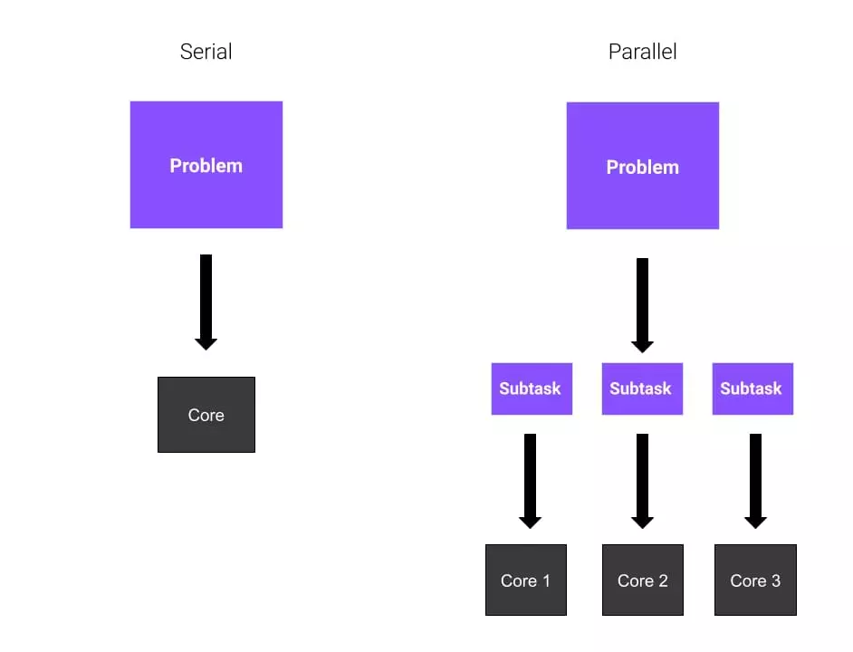

[figure not shown]

# Serial vs Parallel Algorithms

## Serial Execution

- Typical programs operate lines sequentially:

```python
# Import packages
import numpy as np

# Define an array of numbers
foo = np.array([0, 1, 2, 3, 4, 5])

# Define a function that squares numbers
def bar(x):
    return x * x

# Loop over each element and perform an action on it
for element in foo:

        # Print the result of bar
        print(bar(element))
```

```
0
1
4
9
16
25
```

## The map function

- A key tool that we will utilise later is called `map`
- This lets us apply a function to each element in a list or array:

```python
# (Very) inefficient way to define a map function
def my_map(function, array):
    # create a container for the results
    output = []

    # loop over each element
    for element in array:

        # add the intermediate result to the container
        output.append(function(element))

    # return the now-filled container
    return output
```

```python
my_map(bar, foo)
```

```
[0, 1, 4, 9, 16, 25]
```

- Python has a helpfully provided a `map` function in the standard library:

```python
list(map(bar, foo))
```

```
[0, 1, 4, 9, 16, 25]
```

- The built-in `map` function is much more flexible and featured than ours, so of course you should use that one! 😂

## Using `joblib` for parallel computing

- In the example we showed before, no step of the `map` call depend on the other steps
- Rather than waiting for the function to loop over each value, we could create multiple instances of the function `bar` and apply it to each value simultaneously
- There are several methods to achieve this, but we will use `joblib` for this purpose
- The `Parallel` function from `joblib` is used to parallelise the task across as many jobs as we want
- The `n_jobs` parameter specifies the number of jobs to run in parallel
- The `delayed` function is used to delay the execution of the function `bar` until the parallelisation is ready
- The `results` variable will contain the output of the parallel computation
- Using our `bar` function and `foo` array from before:

```python
from joblib import Parallel, delayed

results = Parallel(n_jobs=6)(delayed(bar)(x) for x in foo)
results
```

```
[0, 1, 4, 9, 16, 25]
```

- What `joblib` is doing here is creating 6 instances of the `bar` function and applying each one to a different element of the `foo` array
- As you can see, the results are the same as before
- The difference is that the computation is now done in parallel

## Serial vs parallel execution

- Let’s see another example of the difference between serial and parallel execution
- We will use the `%timeit` magic command to measure the time it takes to run a function
- Serial:

```python
def calculation(size=10000000):
    # Create a large array and perform operations
    arr = np.random.rand(size)
    for _ in range(10):
        arr = np.sqrt(arr) + np.sin(arr)
    return np.mean(arr)

# Single run
%timeit calculation()
```

```
440 ms ± 4.24 ms per loop (mean ± std. dev. of 7 runs, 1 loop each)
```

- Now let’s run the same function 4 times:

```python
# Sequential runs (4 times)
%timeit [calculation() for _ in range(4)]
```

```
1.77 s ± 3.79 ms per loop (mean ± std. dev. of 7 runs, 1 loop each)
```

- Now let’s see the parallel version:

```python
# Parallel runs (4 times)
%timeit Parallel(n_jobs=4)(delayed(calculation)() for _ in range(4))
```

```
605 ms ± 6.57 ms per loop (mean ± std. dev. of 7 runs, 1 loop each)
```

- As you can see, the parallel version is much faster than the serial version
- It is not exactly 4 times faster because there is some overhead in creating the parallel processes
- But the different is still significant

## Another example

### Processing multiple input files

- Say we have a number of input files, like `.jpg` images, that we want to perform the same actions on, like rotate by 180 degrees and convert to a different format
- We can define a function that takes a file as input and performs these actions, then map it on a list of files

```python
# Import python image library functions
from PIL import Image

from matplotlib.pyplot import imshow
%matplotlib inline
```

- Let’s read an image file and display it:

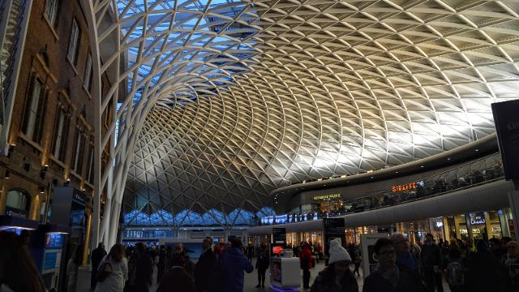

```python
im = Image.open( './data/kings_cross.jpg' )
# Display image
im
```

## Parallel processing of images

- Rotate the image by 180 degrees

[figure not shown]

```python
im.rotate(angle=180)
```

- Let’s define a function that takes a file name as input, opens the file, rotates it upside down, and then saves the output as a PDF:

```python
def image_flipper(file_name):
    # extract the base file name
    base_name = file_name[0:-4]

    # opens the file
    im = Image.open( file_name )

    # rotates by 180deg
    im_flipped = im.rotate(angle=180)

    # Saves a PDF output with a new file name
    im_flipped.save(base_name + "_flipped.pdf", format='PDF')

    return base_name + "_flipped.pdf"
```

## Parallel processing of images

- Let’s see the images we have in the `data` folder:

```python
import glob

file_list = glob.glob('./data/*jpg')

for f in file_list:
    print(f)
```

```
./data/kings_cross.jpg
./data/charing_cross.jpg
./data/victoria.jpg
./data/waterloo.jpg
./data/euston.jpg
./data/fenchurch.jpg
./data/st_pancras.jpg
./data/london_bridge.jpg
./data/liverpool_street.jpg
./data/paddington.jpg
```

- Now let’s apply the `image_flipper` function to each file in the list:

```python
Parallel(n_jobs=4)(delayed(image_flipper)(f) for f in file_list)
```

```
['./data/kings_cross_flipped.pdf',
 './data/charing_cross_flipped.pdf',
 './data/victoria_flipped.pdf',
 './data/waterloo_flipped.pdf',
 './data/euston_flipped.pdf',
 './data/fenchurch_flipped.pdf',
 './data/st_pancras_flipped.pdf',
 './data/london_bridge_flipped.pdf',
 './data/liverpool_street_flipped.pdf',
 './data/paddington_flipped.pdf']
```

## Some take-aways

- Parallel computing can be much faster than serial computing
- These problems are essentially independent and share no information between them
- The `joblib` module makes it simple to run these steps together with a single command
- This workflow is limited to running on a single computer (or compute node) since there is no mechanism to communicate outside

## Try it yourself! 🧠

- Install `joblib` and `numpy` if you haven’t done so yet
  - `!pip install joblib numpy`
- Compare the time of the serial and parallel versions of the following function:

```python
def square(x):
    return x**2

# Create a large array to process
numbers = np.arange(1000000)

# Sequential version
%timeit [square(x) for x in numbers]
```

- Then try the parallel version:

```python
from joblib import Parallel, delayed

# Parallel version
%timeit Parallel(n_jobs=4)(delayed(square)(x) for x in numbers)
```

- What did you find? Is the parallel version faster?
- Appendix 01

# Dask

## Dask

- [Dask](https://dask.org/) is a flexible parallel computing library for analytic computing
- It is composed of two components:
  - Dynamic task scheduling optimised for computation
  - “Big Data” collections like parallel arrays, dataframes, and lists that extend common interfaces like NumPy, Pandas, or Python iterators to larger-than-memory or distributed environments
- Dask emphasises the following virtues:
  - Familiar: Provides parallelised NumPy array and Pandas DataFrame objects
  - Flexible: Provides a task scheduling interface for more custom workloads and integration with other projects
  - Native: Enables distributed computing in pure Python
  - Fast: Operates with low overhead, both in small data and large data settings
- Let’s import Dask and see how it works

```python
import dask.dataframe as dd
import dask.array as da
```

- Dask arrays are a parallel and distributed version of NumPy arrays
- They are composed of many NumPy arrays, split along one or more dimensions

```python
data = np.random.normal(size=100000).reshape(200, 500)
a = da.from_array(data, chunks=(100, 100))
a
```

|  | Array | Chunk |
| --- | --- | --- |
| Bytes | 781.25 kiB | 78.12 kiB |
| Shape | (200, 500) | (100, 100) |
| Dask graph | 10 chunks in 1 graph layer |  |
| Data type | float64 numpy.ndarray |  |

## Dask arrays

- Dask arrays support most of the NumPy functions
- They are lazy, that is, they do not compute anything until you ask for it

```python
a[:10, 5] # first 10 rows of the 6th column
```

|  | Array | Chunk |
| --- | --- | --- |
| Bytes | 80 B | 80 B |
| Shape | (10,) | (10,) |
| Dask graph | 1 chunks in 2 graph layers |  |
| Data type | float64 numpy.ndarray |  |

- We use the `.compute()` method to compute the result

```python
a[:10, 5].compute()
```

```
array([-0.37444792, -0.12032115,  0.96631004,  1.64421129, -0.21111765,
        1.65239234,  1.78607608, -0.64443537,  0.05087629, -1.15887878])
```

## Dask arrays

- Dask Array supports many common NumPy operations including:
- Basic arithmetic and scalar mathematics (`+`, `*`, `exp`, `log`, etc)
- Reductions along axes (`sum()`, `mean()`, `std()`)
- Tensor operations and matrix multiplication (`tensordot`)
- Array slicing and basic indexing
- Axis reordering and transposition

```python
a.sum().compute()
```

```
-7.866101121579902
```

- Let’s compare a similar operation in NumPy:

```python
size = 100000000
np_arr = np.random.random(size)
%timeit np_result = np.sqrt(np_arr) + np.sin(np_arr)
```

```
519 ms ± 13.2 ms per loop (mean ± std. dev. of 7 runs, 1 loop each)
```

- And in Dask:

```python
da_arr = da.random.random(size, chunks='auto')
%timeit da_result = da.sqrt(da_arr) + da.sin(da_arr)
```

```
800 μs ± 2.34 μs per loop (mean ± std. dev. of 7 runs, 1,000 loops each)
```

## Dask dataframes

- Dask also provides a parallelised version of Pandas dataframes
- They are composed of many Pandas dataframes, split along the index
- Let’s jump into an example:

```python
import dask
df = dask.datasets.timeseries()
```

- This is a small dataset of about 240 MB
- Unlike Pandas, Dask DataFrames are lazy, meaning that data is only loaded when it is needed for a computation
- No data is printed here, instead it is replaced by ellipses (`...`)

```python
df
```

**Dask DataFrame Structure:**

| npartitions=30 | name | id | x | y |
| --- | --- | --- | --- | --- |
| 2000-01-01 | string | int64 | float64 | float64 |
| 2000-01-02 | ... | ... | ... | ... |
| ... | ... | ... | ... | ... |
| 2000-01-30 | ... | ... | ... | ... |
| 2000-01-31 | ... | ... | ... | ... |

Dask Name: to_string_dtype, 2 expressions

- Nonetheless, the column names and dtypes are known

```python
df.dtypes
```

```
name    string[pyarrow]
id                int64
x               float64
y               float64
dtype: object
```

## Dask dataframes

- Dask DataFrames support a large subset of the Pandas API
- Some operations will automatically display the data

```python
import pandas as pd

pd.options.display.precision = 2
pd.options.display.max_rows = 10

df.head()
```

| timestamp | name | id | x | y |
| --- | --- | --- | --- | --- |
| 2000-01-01 00:00:00 | Norbert | 959 | 0.52 | -0.57 |
| 2000-01-01 00:00:01 | Quinn | 989 | 0.15 | 0.12 |
| 2000-01-01 00:00:02 | Victor | 948 | -0.54 | -0.58 |
| 2000-01-01 00:00:03 | Bob | 954 | 0.88 | -0.80 |
| 2000-01-01 00:00:04 | Tim | 962 | -0.61 | 0.67 |

- This example shows how to slice the data based on a condition and then determine the standard deviation of the data in the `x` column

```python
df2 = df[df.y > 0]
df3 = df2.groupby("name").x.std()
df3
```

```
Dask Series Structure:
npartitions=1
    float64
        ...
Dask Name: getitem, 8 expressions
Expr=(((Filter(frame=ArrowStringConversion(frame=FromMap(f6d27d5)), predicate=ArrowStringConversion(frame=FromMap(f6d27d5))['y'] > 0))[['name', 'x']]).std(ddof=1, numeric_only=False, split_out=None, observed=False))['x']
```

- Note that `df3` is still not shown
- We can use the `.compute()` method to display the result

```python
df3.compute()
```

```
name
Bob         0.58
Dan         0.58
Edith       0.58
George      0.58
Hannah      0.58
            ...
Patricia    0.58
Tim         0.58
Ursula      0.58
Victor      0.58
Xavier      0.58
Name: x, Length: 26, dtype: float64
```

## Dask dataframes

- Aggregations are also supported
- Here we aggregate the sum of the `x` column and the maximum of the `y` column by the `name` column

```python
df4 = df.groupby("name").aggregate({"x": "sum", "y": "max"})
df4.compute()
```

| name | x | y |
| --- | --- | --- |
| Kevin | -33.64 | 1.0 |
| Sarah | 111.00 | 1.0 |
| Alice | 284.10 | 1.0 |
| Patricia | -178.26 | 1.0 |
| Ingrid | 163.09 | 1.0 |
| ... | ... | ... |
| Jerry | 20.19 | 1.0 |
| Ray | 235.17 | 1.0 |
| Quinn | -100.90 | 1.0 |
| Hannah | -32.22 | 1.0 |
| Dan | 194.80 | 1.0 |

26 rows × 2 columns

- If you have the available RAM for your dataset then you can persist data in memory
- We use the `.persist()` method to do this, and then the data will be available for future computations

```python
df5 = df4.persist()
df5.head()
```

| name | x | y |
| --- | --- | --- |
| Kevin | -33.64 | 1.0 |
| Sarah | 111.00 | 1.0 |
| Alice | 284.10 | 1.0 |
| Patricia | -178.26 | 1.0 |
| Ingrid | 163.09 | 1.0 |

## Time series example

- Since the Dask dataframe we are using has a time series structure, we can use the `resample` method to aggregate the data by a time period
- Let’s resample the data by 1 hour and calculate the mean of the `x` and `y` columns

```python
df[["x", "y"]].resample("1h").mean().head(3)
```

| timestamp | x | y |
| --- | --- | --- |
| 2000-01-01 00:00:00 | 6.63e-03 | -4.72e-03 |
| 2000-01-01 01:00:00 | -6.19e-03 | -2.47e-02 |
| 2000-01-01 02:00:00 | 4.97e-03 | -5.67e-03 |

- We can also use the `rolling` method to calculate a rolling mean of the data

```python
df[["x", "y"]].rolling(window="24h").mean().head()
```

| timestamp | x | y |
| --- | --- | --- |
| 2000-01-01 00:00:00 | 0.52 | -0.57 |
| 2000-01-01 00:00:01 | 0.33 | -0.22 |
| 2000-01-01 00:00:02 | 0.04 | -0.34 |
| 2000-01-01 00:00:03 | 0.25 | -0.46 |
| 2000-01-01 00:00:04 | 0.08 | -0.23 |

## Try it yourself! 🧠

- Install `dask` if you haven’t done so yet
  - `!pip install dask`
- Create a Dask array with 1 million random numbers and calculate the mean of the square root of the array
- Compare the time it takes to run the same operation in NumPy
- Appendix 02

## Dask and SQL

- [dask-sql](https://dask-sql.readthedocs.io/en/stable/) is a library that allows you to run SQL queries on Dask DataFrames
- It is built on top of [Apache Calcite](https://calcite.apache.org/), a SQL interpreter
- It is still under development, but it already has many features
- You can install it with `pip install dask-sql`
- A `dask_sql.Context` is the Python equivalent to a SQL database,
- It serves as an interface to register all tables and functions used in SQL queries, as well as execute the queries themselves
- A single `Context` is created and used for the duration of a Python script or notebook

```python
from dask_sql import Context
c = Context()
```

## Dask and SQL

- Once a `Context` has been created, there are many ways to register tables in it
- The simplest way to do this is through the `create_table` method
- Supported input types include Pandas DataFrames, Dask DataFrames, remote datasets (like on Amazon S3), and more

```python
# Register and persist a dask table
from dask.datasets import timeseries
ddf = timeseries()
c.create_table("dask", ddf, persist=True)
```

```python
c.sql("SELECT AVG(x) FROM dask").compute()
```

|  | AVG(dask.x) |
| --- | --- |
| 0 | 1.17e-04 |

## Dask, SQL and Pandas

- You can of course combine all three libraries!

```python
# Perform a multi-column sort
res = c.sql("""
    SELECT * FROM dask ORDER BY name ASC, id DESC, x ASC
""")

# Now do some follow groupby aggregations
res.groupby("name").agg({"x": "sum", "y": "mean"}).compute()
```

| name | x | y |
| --- | --- | --- |
| Alice | 134.70 | -3.04e-03 |
| Ingrid | -132.42 | 1.69e-03 |
| Kevin | -214.08 | 3.22e-04 |
| Patricia | 311.75 | 1.37e-03 |
| Sarah | 29.90 | 1.05e-03 |
| ... | ... | ... |
| Ray | -22.47 | -2.65e-04 |
| Tim | -87.40 | 2.19e-03 |
| Ursula | -295.27 | 3.79e-04 |
| Wendy | 13.15 | 2.26e-03 |
| Xavier | 346.36 | -1.54e-03 |

26 rows × 2 columns

# Read and write data with Dask

## Reading and writing data

- `.csv` is very common in data science (and for good reasons)
- Pandas reads and writes `.csv` files very well, but it is not the best option for large files
- It may need several gigabytes of memory to read a large file, as it reads the entire file into memory
- Dask provides a [much more efficient way](https://docs.dask.org/en/latest/dataframe-create.html) to read and write `.csv` files
- Let’s split our dataset

```python
df = dask.datasets.timeseries()
df
```

**Dask DataFrame Structure:**

| npartitions=30 | name | id | x | y |
| --- | --- | --- | --- | --- |
| 2000-01-01 | object | int64 | float64 | float64 |
| 2000-01-02 | ... | ... | ... | ... |
| ... | ... | ... | ... | ... |
| 2000-01-30 | ... | ... | ... | ... |
| 2000-01-31 | ... | ... | ... | ... |

Dask Name: make-timeseries, 1 expression

```python
import os
import datetime

if not os.path.exists('data'):
    os.mkdir('data')

def name(i):
    """ Provide date for filename given index

    Examples
    --------
    >>> name(0)
    '2000-01-01'
    >>> name(10)
    '2000-01-11'
    """
    return str(datetime.date(2000, 1, 1) + i * datetime.timedelta(days=1))

df.to_csv('data/*.csv', name_function=name);
```

## Reading and writing data

- We now have many CSV files in our `data` directory, one for each day in the month of January 2000
- Each CSV file holds timeseries data for that day
- We can read all of them as one logical dataframe using the `dd.read_csv` function

```python
df = dd.read_csv('data/2000-*-*.csv')
df
```

**Dask DataFrame Structure:**

| npartitions=30 | timestamp | name | id | x | y |
| --- | --- | --- | --- | --- | --- |
|  | object | object | int64 | float64 | float64 |
|  | ... | ... | ... | ... | ... |
| ... | ... | ... | ... | ... | ... |
|  | ... | ... | ... | ... | ... |
|  | ... | ... | ... | ... | ... |

Dask Name: read_csv, 1 expression

- Let’s do a simple computation

```python
%timeit df.groupby('name').x.mean().compute()
```

```
785 ms ± 155 ms per loop (mean ± std. dev. of 7 runs, 1 loop each)
```

## Reading and writing data

### Parquet files

- Although `.csv` files are nice, new formats like [Parquet](https://parquet.apache.org/) are gaining popularity
- Data are stored by column rather than by row, allowing for efficient querying of specific columns without reading entire rows
- It can be used with various programming languages and data processing frameworks
- Achieves up to 75% reduction in file size compared to uncompressed formats

```python
df.to_parquet('data/2000-01.parquet', engine='pyarrow')
```

- Now we can read the parquet file

```python
df = dd.read_parquet('data/2000-01.parquet', columns=['name', 'x'], engine='pyarrow')
df
```

**Dask DataFrame Structure:**

| npartitions=30 | name | x |
| --- | --- | --- |
|  | object | float64 |
|  | ... | ... |
| ... | ... | ... |
|  | ... | ... |
|  | ... | ... |

Dask Name: read_parquet, 1 expression

- Let’s do the same computation as before

```python
%timeit df.groupby('name').x.mean().compute()
```

```
191 ms ± 4.84 ms per loop (mean ± std. dev. of 7 runs, 1 loop each)
```